# Capstone project: NLP

Miguel Levy

Saturday, March 28, 2015

## SUMMARY

The study of human and text expressions in social media give us a powerful tool for understand and recognize from the meaning of a phrase to the mood of a person. A set of powerful A.I. technologies knowns as Natural Language Processing (NLP) and text mining, enable to the computers for the processing of written and spoken text.

This report reviews a set of twitter data, news articles, and blog posts provided by SwiftKey and make an primary exploratory analysis.

**GOALS:**

```
1.- Demonstrate how the data were downloaded and successfully loaded it in.
2.- Create a basic report of summary statistics about the data sets.
3.- Give a first feedback about plans of creating a prediction algorithm and Shiny app.
```

## MATERIALS AND METHODS - DATA SOURCES:

The data was collected from publicly available sources by a web crawler and numerous different webpages written in various languages (Finnish, German, US-English and Russian), you can get more information in this URL: http://www.corpora.heliohost.org/aboutcorpus.html.

For this project we use the english database located in a folder with three files: **en_US.blogs.txt**,**en_US.news.txt**,**en_US.twitter.txt**.

**LOADING AND CLEANING DATASETS:** First of all we need to download the data and obtain some basic summary statistics.

```r
urlfile <- "https://d396qusza40orc.cloudfront.net/dsscapstone/dataset/Coursera-SwiftKey.zip"
target_file <- "./Data/Coursera-SwiftKey.zip"

#variables files english
path_en_files <- sprintf('%s/Data/final/en_US/',getwd())
blog_file <- paste(path_en_files,'en_US.blogs.txt', sep="")
twitter_file <- paste(path_en_files,'en_US.twitter.txt', sep="")
news_file <- paste(path_en_files,'en_US.news.txt', sep="")

# Check if folder with data exist: If exist load data,
#       else -> create folder and load data.

if (!file.exists("Data")){
    dir.create("Data")
    #Download and unzip dataset
    download.file(urlfile, destfile = target_file, method = "auto")
    unzip("./Data/Coursera-SwiftKey.zip", exdir="./Data")
}
```

Now we are going to examine the contents of these files with partial examples:

```
## [1] "In the years thereafter, most of the Oil fields and platforms were named after pagan \"gods\"."
## [2] "We love you Mr. Brown."
```

```
## [1] "It is #RHONJ time!!"
## [2] "The key to keeping your woman happy= attention, affection, treat her like a queen and sex her like a pornstar!"
```

```
## [1] "He wasn't home alone, apparently."
## [2] "The St. Louis plant had to close. It would die of old age. Workers had been making cars there since the onset of mass automotive production in the 1920s."
```

Now some statistics:

a.- Size of files in MB:

```r
#files size
size_files <- c(paste("Blog file:", as.integer(file.info(blog_file)$size / 1024^2,sep="")),paste("Twitter file:",  as.integer(file.info(twitter_file)$size / 1024^2, sep="")), paste("News file:", as.integer(file.info(news_file)$size / 1024^2, sep="")))
```

```
## [1] "Blog file: 200"
```

```
## [1] "Twitter file: 159"
```

```
## [1] "News file: 196"
```

b.- `Num. of lines` by file:

```r
#We use functions from library stringi
#num lines and charts by file:
content_files <- c(paste('Blog file: ',stri_stats_general(blogs),'Twitter file: ',stri_stats_general(twitter),'News file: ',stri_stats_general(news)))
```

```
## [1] "Blog file:  899288 Twitter file:  2360148 News file:  77259"
```

c.- `Núm. charts` by file:

```
## [1] "Blog file:  206860471 Twitter file:  162225255 News file:  15639803"
```

d.- `Núm. of words` by file:

```r
words_files <- c(paste('Blog file: ',sum(stri_count_words(blogs)),'Twitter file: ',sum(stri_count_words(twitter)),'News file: ',sum(stri_count_words(news))))
```

```
## [1] "Blog file:  37530473 Twitter file:  30091531 News file:  2674528"
```

The total data size is greater than 500 MB, we randomly select three samples of 20000 records from each file to buid a sample data set. Is not possible to run a model using all data, for processing time and hardware resources limitations.

```r
blogs_sample <- sample(blogs, 20000)
news_sample  <- sample(news, 20000)
twitter_sample <- sample(twitter, 20000)
# sample data set
sample_dataset <- c(blogs_sample, news_sample, twitter_sample)
```

**CLEANING DATASET:** We are going to clean the sample dataset Using `tm` and `weka` libraries to create a ‘corpus’ of this dataset:

```
a.- Change Upper case to lower case.
b.- Remove numbers
c.- Remove punctuation.
d.- Remove English stopwords (“the”, “is”, “at”, “which”...)
e.- Remove unnecessary spaces from the dataset.
```

```r
library("tm")
Corpus_dataset <- Corpus(VectorSource(list(sample_dataset)))
Corpus_dataset <- tm_map(Corpus_dataset, content_transformer(tolower))
Corpus_dataset <- tm_map(Corpus_dataset, content_transformer(removePunctuation))
Corpus_dataset <- tm_map(Corpus_dataset, content_transformer(removeNumbers))
Corpus_dataset <- tm_map(Corpus_dataset,removeWords, stopwords("english"))
Corpus_dataset <- tm_map(Corpus_dataset,stripWhitespace)
```

Now we have texts which components are not structured and need to transform to elements for apply some statistical method to build prediction algoritms. This step is known as n-gram (see http://en.wikipedia.org/wiki/N-gram).

Plot for 1-gram, one word top frequencies:

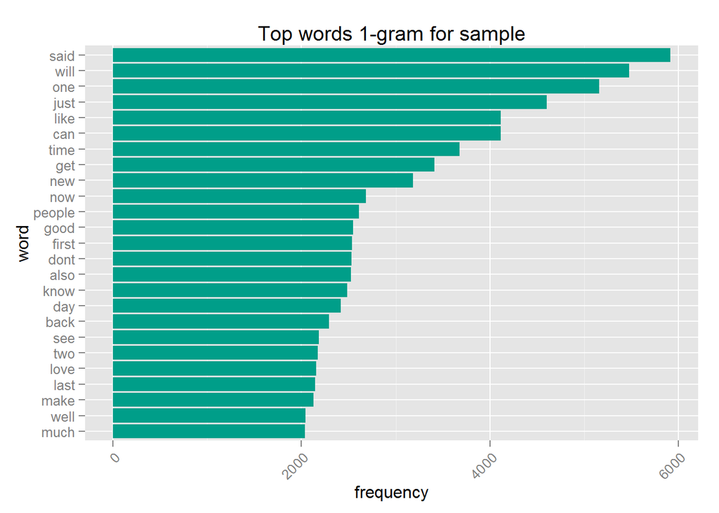

**CONCLUSIONS:**

This preliminary analysis was a first aproximation to construct a predictive algorithm for text prediction using NLP. It´s was possible using a unique sample corpus buid from three differents text files. The text prediction depend of the languaje employed in each media file. It´s not same the expressions used in twitter chat respect the expressions used in news or blog texts files.

I think is better extend this preliminary study analyzing the n-gram for individual files, is possible will be necessary to build two or three predictive algorithms adapted to each language (twitter, news and blogs).